[figure not shown]

[OHI-Northeast](http://www.ohi-northeast.org/) | [OHI Science](http://ohi-science.org) | [Citation policy](http://ohi-science.org/citation-policy/)

# Trash data layer

Compiled on Mon Jul 30 16:13:29 2018 by afflerbach

## Summary

The trash layer is derived from [Ocean Conservancy data](https://oceanconservancy.org/trash-free-seas/international-coastal-cleanup/annual-data-release/)) on the pounds of trash collected on International Coastal Cleanup Day.

```r
knitr::opts_chunk$set(fig.width = 10, fig.height = 6, fig.path = 'figs/', message = FALSE, warning = FALSE)

source('~/github/ne-prep/src/R/common.R')

library(tidyverse)
```

## Data Wrangling

This data was manually copied and pasted from the [Ocean Conservancy website](https://oceanconservancy.org/trash-free-seas/international-coastal-cleanup/annual-data-release/) as it is not provided in an easy to use format. The “raw” data is an excel file with one sheet for each year. There are also some weird issues like a mix of lower and uppercase letters for the states.

The data is filtered to only those states in our regions (NY to Maine) and I add in a column, `pounds_per_person` which calculates the total pounds per volunteer.

```r
clean_func <- function(year) {

raw <- readxl::read_excel(file.path(dir_anx, "_raw_data/OceanConservancy/CoastalCleanup_Data.xlsx"), sheet = year) %>%
  mutate(year = as.numeric(year),
         state = tolower(.[[1]]),
         people = .[[2]],
         pounds = as.numeric(.[[3]])) %>% #for some reason one of the sheets was having pounds read in as character. forcing it to numeric here
  select(year, state, people, pounds) %>%
  filter(state %in% c("new york", "connecticut", "maine", "massachusetts", "rhode island", "new hampshire")) %>%
  mutate(pounds_per_person = pounds/people)

return(raw)
}

years <- as.character(c(2006:2017)) #need to be characters to use years as sheet names in read_excel

out <- map_df(years, clean_func)
```

## Visualize data

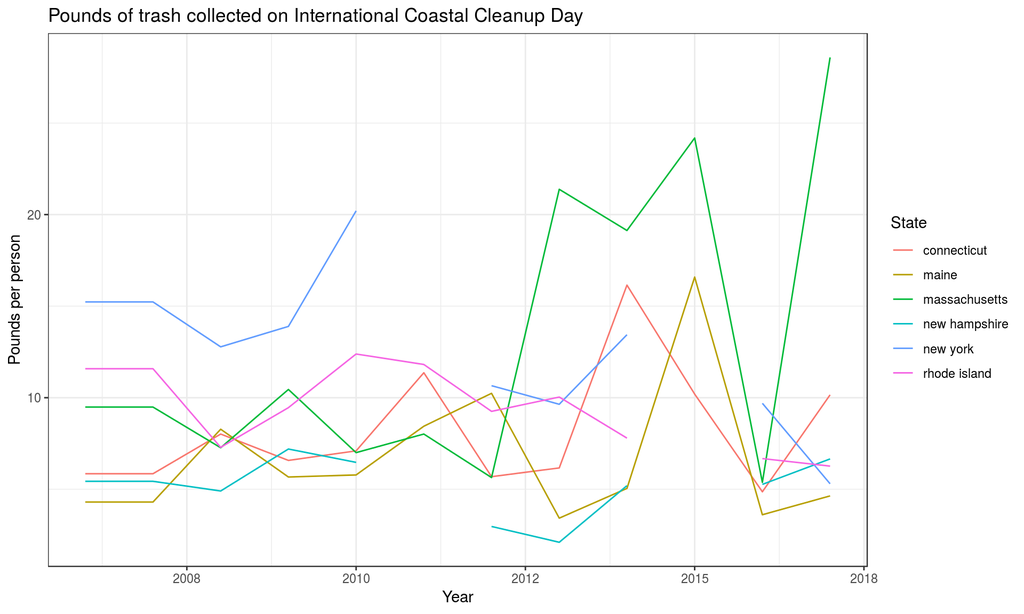

```r
# I believe NY and NH are missing data from 2011. So I'm adding in NAs

out_gf <- out %>%
  complete(year, state)

ggplot(out_gf, aes(x = year, y = pounds_per_person, color = state)) +
  geom_line() +
  theme_bw() +
  labs(x = "Year",
       y = "Pounds per person",
       title = "Pounds of trash collected on International Coastal Cleanup Day",
       color = "State")
```

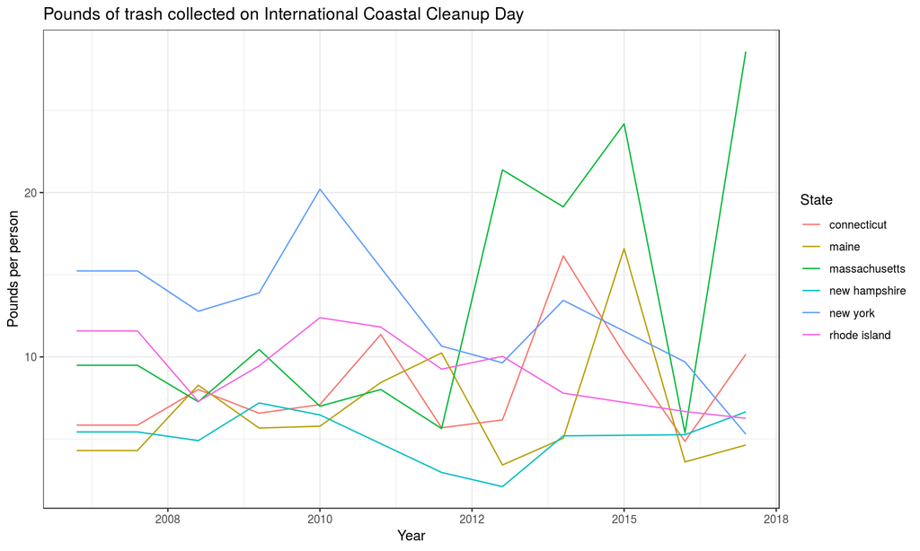

```r
gapfilled_df <- out_gf %>%
  group_by(state) %>%
  mutate(pounds_pp = zoo::na.approx(pounds_per_person)) %>%
  ungroup()

ggplot(gapfilled_df, aes(x = year, y = pounds_pp, color = state)) +
  geom_line() +
  theme_bw() +
  labs(x = "Year",
       y = "Pounds per person",
       title = "Pounds of trash collected on International Coastal Cleanup Day",
       color = "State")
```

## Save layer for toolbox

```r
rgns <- rgn_data %>%
  data.frame() %>%
  mutate(state = tolower(state))

gapfilled_df %>%
  left_join(rgns) %>%
  select(year, rgn_id, pounds_pp) %>%
  complete(rgn_id = 1:11, #this adds in regions 1-4 with NA values for pounds_pp
           year) %>%
  write.csv(file.path(dir_calc, "layers/cw_trash.csv"))
```